# Dealing with Heterogeneity

Statistical and Geospatial Modelling

Alejandro Ordonez

# Instructions

## Before you start.

The practical will be run using *RStudio cloud* to avoid individual machine troubleshooting. Therefore, you **need** to have an account for *RStudio cloud*.

However, remember to have `R` (https://cran.r-project.org) and R-studio (http://www.rstudio.com/) in your/room computer so you can work on the project after class.

## The goal.

This practical aims to implement what you have learned in the class about generalised linear regressions in `R`. You should have read the chapters I uploaded beforehand **(You should have read chapter 19 of Crawley, M.J., 2012. The R-book**

## Learning objectives.

1. Be able to distinguish if a model suffers from heterogeneity in the residual.
2. Discriminate between different strategies to address heterogeneity in the residuals.
3. Know how to Implement a generalised linear model in `R`, that can address heterogeneity in the residuals.

## The way it’s going to be run.

A 3h practical. You will need to write your own `R` and run it - this is what you will hand in. I know you will struggle, but that is the best way to learn to use `R`. Also, remember that you have an excellent teaching assistant - ask all the questions you have, but **WE WILL NOT WRITE YOUR CODE!!.**

The text in the blue box marked as **Your task:** states what you need to do

```r
# The code in the window marked like this shows where you need to write your code
#
# If I ask you to assess the result, you should write the text here as a comment starting with two hashes (##)
```

## Assessment:

Submit your `R-markdown` file via BrightSpace - **Before the next practical!** **The assessment is a Pass/Fail based on how you write and annotate the code - You need to show us you know what you are doing and NOT copying someone else’s code.**

# Key things to remember.

Up to this point, we have treated all categorical explanatory variables as if they were the same. However, explanatory variables are not all created equal. There are fundamentally different sorts of explanatory variables *fixed effects* and *random effects*.

The short version of the differences between these focuses on each of these explanatory variables ($X_i$) affecting your response variable ($Y$). While **fixed effects** influence only the mean of ($Y$), **random effects** influence only ($Y$) variance. *What does this mean in practical terms?* well, **fixed effects** define the mean response (the mean regression slopes). By comparison, **random effects** govern the variance of the response (you could say the covariance structure of the response variable, and hence their standard errors).

One example of random effects is the hierarchical structure of a sample design that leads to pseudoreplication. To address this, you could concentrate on estimating means of our smaller subset of the data - but that will limit your capacity to draw meaningful conclusions from your data. Much better to recognise them for what they are, random samples from a much larger population, and to concentrate on their variance - *This is the added variation caused by differences between the levels of the random effects*.

However, sometimes the added and uneven variability can not be attributed to a random effect. In that case, you would need to model the variability to address the variability problem.

Here is when *Mixed Effects* and * generalised least squares* (GLS) models come to the rescue. The difference is that mixed-effects models allow for nested hierarchical structured datasets and known covariates when modelling the extra variation/heterogeneity. If you use the current data to model the additional variation/heterogeneity, you have a GLS model.

Now you will proceed to build both of these models. It is important to remember that we build from the general(ized) linear models knowledge gained over the last weeks. So I will not spend too much space explaining essential knowledge points about each task.

# Benthic Biodiversity Experiment

*[Ieno EN, Solan M, Batty P, Pierce GJ (2006) How biodiversity affects ecosystem functioning: roles of infaunal species richness, identity and density in the marine benthos. Marine Ecology Progress Series 311:263–271]*

Here you will examine the hypothesis that changes in the composition of benthic macrofauna alter the biogeochemistry of coastal intertidal mudflats. For this, we will assess how changes in macrofauna density (`Biomass`, [mg] of the Polychaeta *Hediste diversicolor*), and habitat heterogeneity (`Treatment`, Algae/NoAlgae) changes the rates of sediment Nutrient release (`Concentration`, [mg-1 per l]), of three different `Nutrient`s (`Nutrient`, $NO_3$ [nitrate-nitrogen], $NH_4$ [Ammonium-nitrogen], $PO_3$ [phosphate-phosphorus]). To do so, we will use experimental data from Leno et al., (2006) and unpublished data from Oceanlab (University of Aberdeen). The original data also contained data on two other benthic invertebrates (*Hydrobia ulvae* [Gastropoda] and *Cerastoderma edule* [Bivalvia]) which will **NOT BE USED** here.

## The first step: Loading the data

The first step you will have to take when making any data analysis is to load your data. During last week session, you practised how to do this.

**Your task:**

Using the function `read.csv`, load the data from *Biodiversity.csv*, located in the Web URL https://raw.githubusercontent.com/AlejoOrdonez/StaGeoMod2021/main/Biodiversity.csv. For this:

- Define an object named URL.Loc with the string of the Web URL.
- Use `read.csv` to load the file - The file is comma-separated

```r
## Define an object named URL.Loc with the string of the Web URL
URL.Loc <- "https://raw.githubusercontent.com/AlejoOrdonez/StaGeoMod2021/main/Biodiversity.csv"

## Use `read.csv` to load the file and save it as an object named green
## The file Biodiversity.csv is a Comma-separated file
ieno <- read.csv(URL.Loc)
```

## Data Exploration

Now, explore how `Concentration` of each `Nutrient` changes as a function of `Biomass`, `Treatment`.

**Your task:**

Using the `coplot()` function evaluate how `Concentration` changes as a function of `Biomass` and `Nutrient`. Use the variable `Treatment` to define colours in your plot. Remember, if you do not know how to use a function, you can ask `R` using `?coplot`.

Based on this figure, describe:

- The pattern between `Nutrient`s in the response of `Concentration` to changes in `Biomass`.
- What about the effect of Algal enrichment (`Treatment`)?

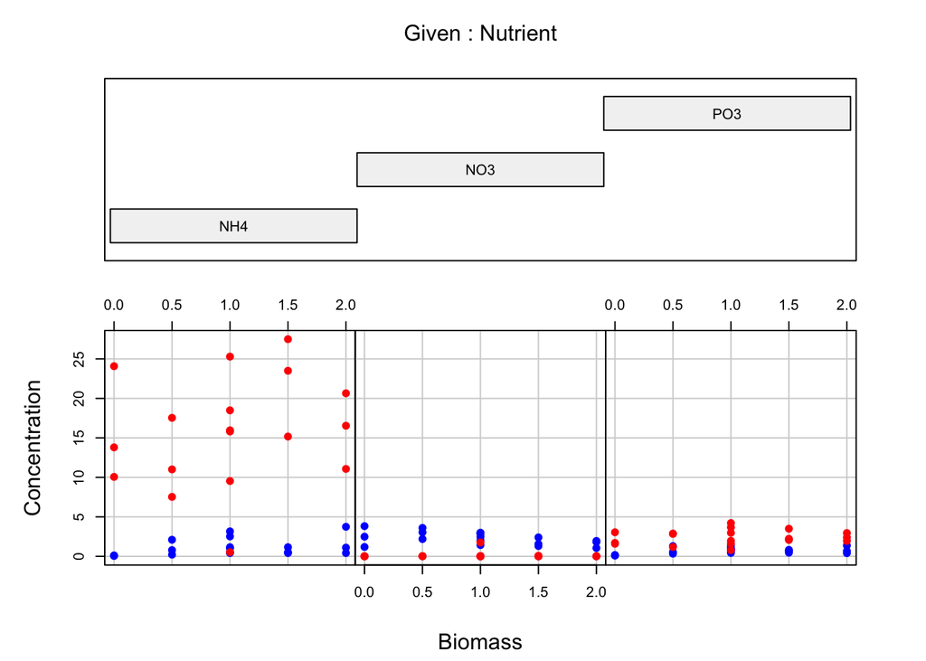

```r
# Define the colours for Algae and NoAlgae (the treatments)
ColPlot <- ifelse(ieno$Treatment == "Algae", # set the colours using Treatment
  "red", "blue" # red = algae
)
# Use the coplot() function to evaluate how `Concentration` changes as a function of `Biomass` and `Nutrient
coplot(Concentration ~ Biomass | Nutrient, #
  data = ieno, # Specify the name of the object where the data can be found
  columns = 3, # Number of columns in the panel layout array
  pch = 19, # Make the points filled circles
  col = ColPlot # set the colours using Treatment
)
```

```r
# Describe the pattern between `Nutrient`s in the response of `Concentration` to changes in `Biomass`.
## There is a differential effect on the rates of sediment nutrient release based on the combination of macrofauna density and habitat heterogeneity. The available Nutrients modulate these differences. $NO_3$ decreases with macrofauna Biomass when there is no algae treatment but is unaffected when algae are present. Neither $NH_4$ nor $PO_3$ have any clear linear patterns in response to Biomass.

# What about the effect of Algal enrichment (`Treatment`).
## Algae treatment leads to increased release of $NH_4$ and $PO_3$, but decreases release of $NO_3$.
```

## A closer look at the response - predictor relation.

You could analyse this dataset by focusing on each of the three measured `Nutrient`s independently. However, it is more interesting to combine all the different `Nutrient’-data and analyse it all simultaneously. We will use such an approach here as it allows you to test for interactions between nutrients and treatment levels. Before we do this, let’s look at the predictors one more time.

**Your task:**

Plot the changes in `Concentration` as a function of algal enrichment (`Treatment`) and `Nutrient`s using the `boxplot()` function.

Do you see differences in the variation of `Concentration` per `Nutrient`-`Treatment` combination?

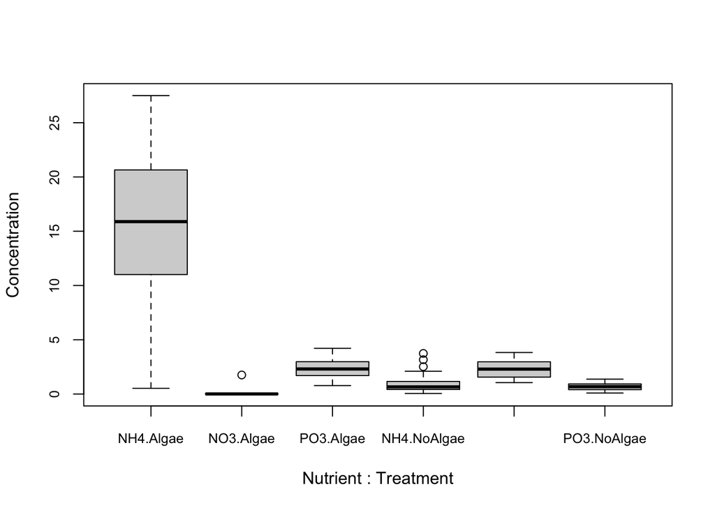

```r
# Use a boxplot to link nutrient concentration to the Nutrient/Treatment interaction.
boxplot(Concentration ~ Nutrient * Treatment, # use formula to link Concentration to the  Nutrient/Treatment interaction.
  data = ieno, # Specify the name of the object where the data can be found
  cex.axis = 0.8, # Specify the side of the x-axis labels
  ylab = "Concentration" # name of the variable in the y-axis
)
```

```r
# Do you see differences in the variation of `Concentration` per `Nutrient`-`Treatment` combination?
### There is a considerable variation in $NH_4$ when there is Algae. All others have pretty low variation. This could complicate our assessment of biodiversity effects (Biomass) on the Concentration of evaluated Nutrients and justifies using a generalised least squares model.
```

One problem with the visualisation above is that the samples enriched with algae and NH<sub>4</sub> have higher concentrations and more variation than the other combinations. One way to “visualise” the differences with the different Treatment/Nutrient combinations is plotting the Log<sub>10</sub> or `Concentration` as a function of `Nutrient` and `Treatment`. I leave that task to the Inquisitive of you, but the output is presented below.

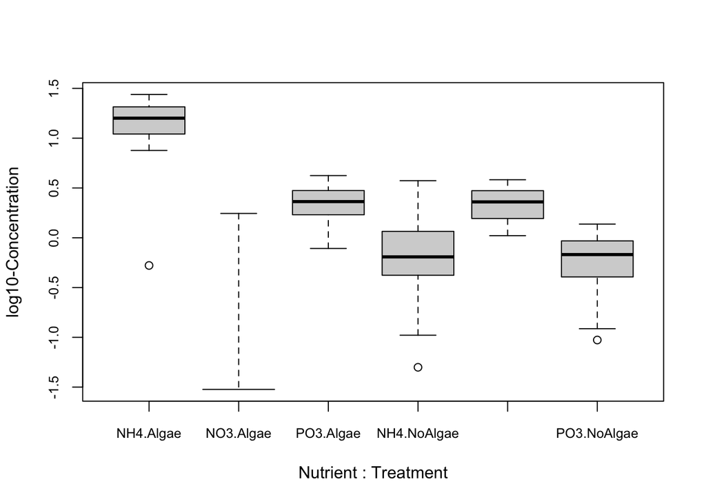